# QTM 151 - Introduction to Statistical Computing II

Lecture 21 - Time Series

Danilo Freire

danilo.freire@emory.edu

Emory University

13 November, 2024

# Hello, friends! 😊 Having a good day?

# Brief recap 📝

## Last class we saw…

- How to use the `JOIN` statement to combine data from different tables
- Different types of `JOIN` statements, such as `INNER JOIN`, `LEFT JOIN`, `RIGHT JOIN`, and `FULL JOIN`
- What Entity-Relationship Diagrams are and how to use them to understand the relationships between tables
- How to use `pd.to_sql()` to write data to a SQL database from a DataFrame

[figure not shown]

# Today’s plan 📅

## Time Series

- Today we will learn about time series data
- We will see how to work with time series data in Python
- We will learn how to use the `datetime` module to work with dates and times
- We will also visualise time series data using `matplotlib`
- Finally, we will learn how to convert time series to strings and calculate aggregates

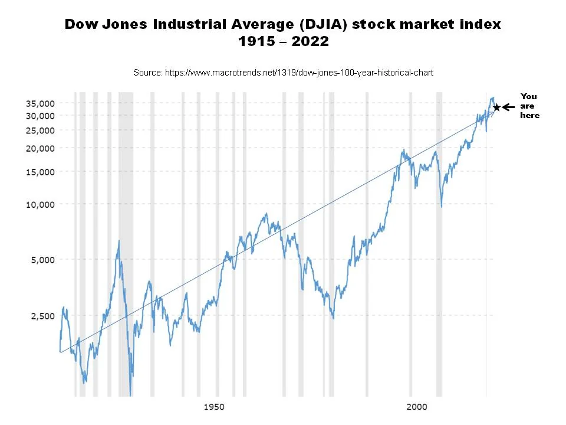

# Time Series 🕰️

## What is time series data?

- Time series data is a sequence of data points collected at constant time intervals
- These data are used in many fields, such as economics, finance, and meteorology
- They are used to predict future values based on past observations
- We usually decompose time series data into trend, seasonality, and noise
- Trend: long-term increase or decrease in the data
- Seasonality: repeating patterns in the data
- Noise: random fluctuations in the data

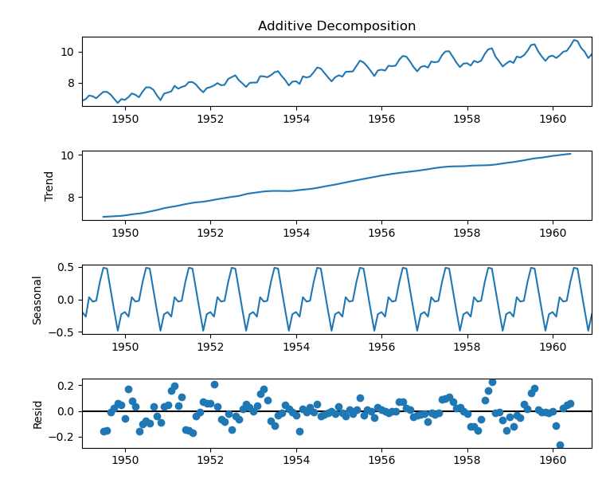

# Time Series in Python 🐍

## Working with time series data in Python

- In Python, we can use the `datetime` module to work with dates and times
- It provides some useful functions to manipulate time series data, and it works well with `pandas` and `matplotlib`
- Let’s load the packages we need

```python
# "pandas" processes datasets
# "maplotlib.pyplot" generates graphs
# "maplotlib.dates" has options for plotting dates
# "datetime" handles date information

import pandas as pd
import matplotlib.pyplot as plt
import matplotlib.dates as mdates
from datetime import date, time, datetime
```

- Now let’s import the data we will use

```python
# Load the data
financial = pd.read_csv("data_raw/financial.csv")
financial.head()
```

|  | date_str | sp500 | djia | date_ex1 | date_ex2 | date_ex3 |
| --- | --- | --- | --- | --- | --- | --- |
| 0 | 4/4/2018 | 2644.69 | 24264.30 | April 04 2018 | Wednesday, 2018-04-04 | 4-Apr-18 |
| 1 | 4/5/2018 | 2662.84 | 24505.22 | April 05 2018 | Thursday, 2018-04-05 | 5-Apr-18 |
| 2 | 4/6/2018 | 2604.47 | 23932.76 | April 06 2018 | Friday, 2018-04-06 | 6-Apr-18 |
| 3 | 4/9/2018 | 2613.16 | 23979.10 | April 09 2018 | Monday, 2018-04-09 | 9-Apr-18 |
| 4 | 4/10/2018 | 2656.87 | 24408.00 | April 10 2018 | Tuesday, 2018-04-10 | 10-Apr-18 |

- `sp500` is the [S&P 500 index](https://en.wikipedia.org/wiki/S%26P_500)
- `djia` is the [Dow Jones Industrial Average](https://en.wikipedia.org/wiki/Dow_Jones_Industrial_Average)

## Parsing dates in Python

- Date columns are strings by default
- We can convert them to `datetime` objects using the `pd.to_datetime()` function
- This function can handle different date formats
- If the conversion is simple, we can use the `parse_dates` argument in `pd.read_csv()`
  - `financial = pd.read_csv("data_raw/financial.csv",parse_dates = ["date"])`
- Let’s parse the first column, `date_str`, to a `datetime` object

```python
# Convert the date column to datetime
financial["date"] = pd.to_datetime(financial["date_str"])
financial.head()
```

|  | date_str | sp500 | djia | date_ex1 | date_ex2 | date_ex3 | date |
| --- | --- | --- | --- | --- | --- | --- | --- |
| 0 | 4/4/2018 | 2644.69 | 24264.30 | April 04 2018 | Wednesday, 2018-04-04 | 4-Apr-18 | 2018-04-04 |
| 1 | 4/5/2018 | 2662.84 | 24505.22 | April 05 2018 | Thursday, 2018-04-05 | 5-Apr-18 | 2018-04-05 |
| 2 | 4/6/2018 | 2604.47 | 23932.76 | April 06 2018 | Friday, 2018-04-06 | 6-Apr-18 | 2018-04-06 |
| 3 | 4/9/2018 | 2613.16 | 23979.10 | April 09 2018 | Monday, 2018-04-09 | 9-Apr-18 | 2018-04-09 |
| 4 | 4/10/2018 | 2656.87 | 24408.00 | April 10 2018 | Tuesday, 2018-04-10 | 10-Apr-18 | 2018-04-10 |

- We can check the types of the columns using `financial.dtypes`

```python
financial.dtypes
```

```
date_str            object
sp500              float64
djia               float64
date_ex1            object
date_ex2            object
date_ex3            object
date        datetime64[ns]
dtype: object
```

# Visualise time series data 📊

## Plotting time series data

- First, let’s see where our data begins and ends
- You can do it in many ways

```python
financial['date'][0]
```

```
Timestamp('2018-04-04 00:00:00')
```

```python
financial['date'][len(financial) - 1] # why -1 here?
```

```
Timestamp('2023-04-04 00:00:00')
```

- Or you can use the `min()` and `max()` functions

```python
print("Start date:", financial["date"].min())
```

```
Start date: 2018-04-04 00:00:00
```

```python
print("End date:", financial["date"].max())
```

```
End date: 2023-04-04 00:00:00
```

- Or just use `head()` and `tail()` as we did before
- We can now plot the data
- As you may remember, `plt.plot()` is used to create line plots
- The first two arguments are column names for the `(x,y)` data
- The third argument is the data
- Make sure that the data is sorted, since the lines will be connected based on the order of the dataset
- We can sort the data using `financial.sort_values("date")`
- Let’s plot the data 🤓

## Plotting time series data

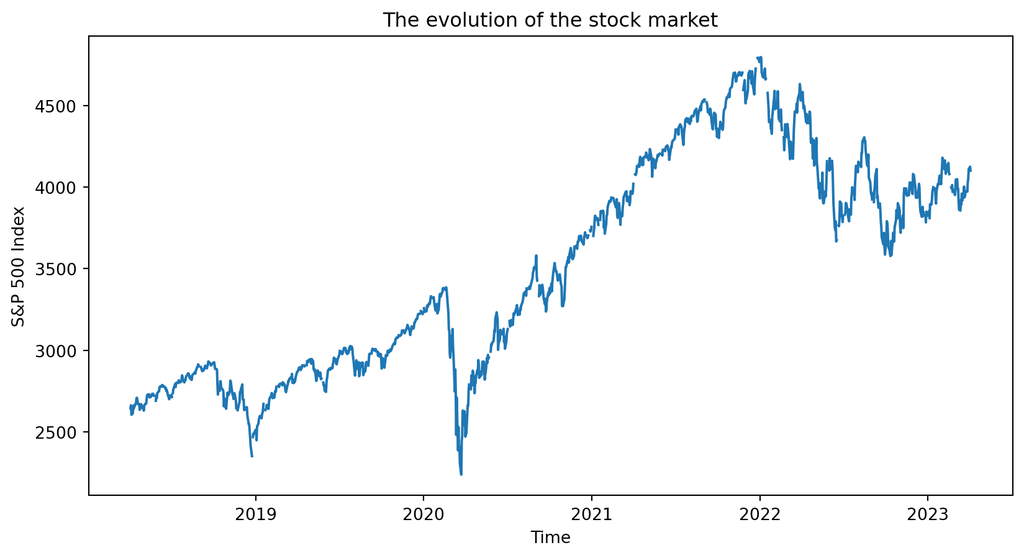

```python
# Sort the data
financial = financial.sort_values("date")

# Plot the data
plt.plot("date", "sp500", data = financial)
plt.xlabel("Time")
plt.ylabel("S&P 500 Index")
plt.title("The evolution of the stock market")
plt.show()
```

## Try it yourself! 🧠

- Now it’s your turn! 🚀
- Plot the `djia` column on the `y` axis and the `date` column on the `x` axis
- Make sure to sort the data first
- Appendix 01

## S&P 500 vs. Dow Jones Industrial Average

- As you may have guessed, although the indices are calculated in different ways, they are highly correlated
- The S&P 500 is a broader index, while the Dow Jones is more focused on industrial companies
- The S&P 500 is considered a better representation of the overall stock market
- Let’s see how the two indices compare

```python
# Correlation between the two indices
financial[["sp500", "djia"]].corr()
```

|  | sp500 | djia |
| --- | --- | --- |
| sp500 | 1.000000 | 0.981448 |
| djia | 0.981448 | 1.000000 |

- Let’s plot the two indices together

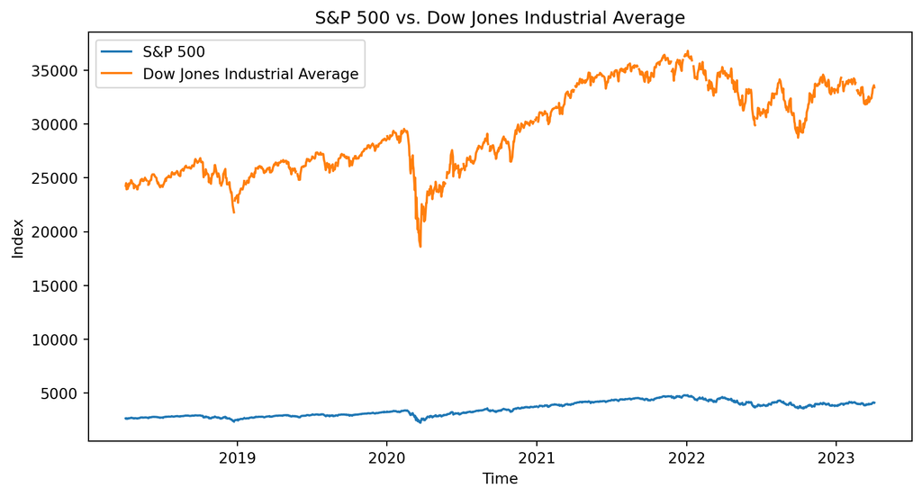

```python
plt.plot("date", "sp500", data = financial, label = "S&P 500")
plt.plot("date", "djia", data = financial, label = "Dow Jones Industrial Average")
plt.xlabel("Time")
plt.ylabel("Index")
plt.title("S&P 500 vs. Dow Jones Industrial Average")
plt.legend()
plt.show()
```

## Oops, that looks a bit messy 🤔

- The indices are calculated differently, so the values are not directly comparable
- We can normalise the indices to start from the same point
- We do so by dividing each index by its initial value (why?)

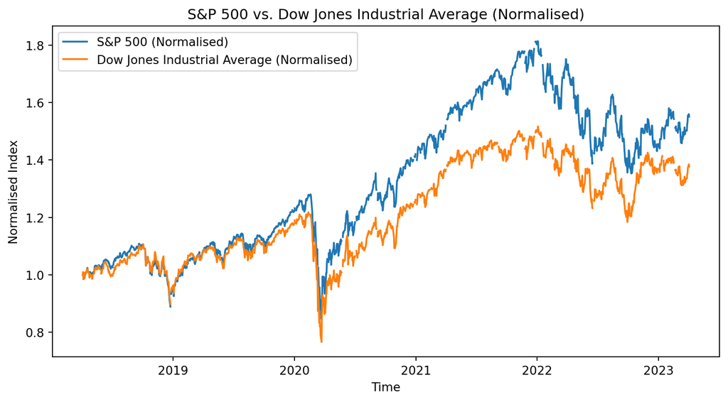

```python
# Normalise the indices to start from the same point
financial["sp500_normalised"] = financial["sp500"] / financial["sp500"].iloc[0]
financial["djia_normalised"] = financial["djia"] / financial["djia"].iloc[0]

# Plot the normalized data
plt.plot("date", "sp500_normalised", data = financial, label = "S&P 500 (Normalised)")
plt.plot("date", "djia_normalised", data = financial, label = "Dow Jones Industrial Average (Normalised)")
plt.xlabel("Time")
plt.ylabel("Normalised Index")
plt.title("S&P 500 vs. Dow Jones Industrial Average (Normalised)")
plt.legend()
plt.show()
```

# Dates + Wild Cards = Fun! 🎉

## Converting time series to strings

- We can convert `datetime` objects to strings using the `strftime()` method
- The first argument needs to be a datetime type
- The second argument is the format you want to use
- A wildcard `%` is used to denote date formats
- For example, `%Y` is the year, `%m` is the month, and `%d` is the day
- `%H` is the hour, `%M` is the minute, and `%S` is the second

```python
financial["month_str"] = financial["date"].dt.strftime("%m")
print(financial["month_str"].head(3))
```

```
0    04
1    04
2    04
Name: month_str, dtype: object
```

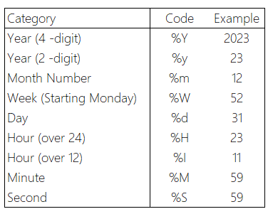

```python
financial["week_str"]  = financial["date"].dt.strftime("%W")
print(financial["week_str"].head(3))
```

```
0    14
1    14
2    14
Name: week_str, dtype: object
```

## Converting time series to strings

- We can also convert dates to names

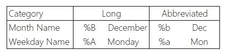

```python
financial["monthname"]   =  financial["date"].dt.strftime("%B")
print(financial["monthname"].head(3))
```

```
0    April
1    April
2    April
Name: monthname, dtype: object
```

```python
financial["weekdayname"] =  financial["date"].dt.strftime("%A")
print(financial["weekdayname"].head(3))
```

```
0    Wednesday
1     Thursday
2       Friday
Name: weekdayname, dtype: object
```

## Personalise your dates 🎨

- We can also customise the date format
- For example, we can use the following format to display the date as `YYYY-MM-DD`

```python
financial["date_str"] = financial["date"].dt.strftime("%Y-%m-%d")
print(financial["date_str"].head(3))
```

```
0    2018-04-04
1    2018-04-05
2    2018-04-06
Name: date_str, dtype: object
```

```python
message_monthname =  financial["date"].dt.strftime("This is the month of %B")
print(message_monthname.head(3))
```

```
0    This is the month of April
1    This is the month of April
2    This is the month of April
Name: date, dtype: object
```

```python
message_monthday  =  financial["date"].dt.strftime("The day of the week is %A")
print(message_monthday.head(3))
```

```
0    The day of the week is Wednesday
1     The day of the week is Thursday
2       The day of the week is Friday
Name: date, dtype: object
```

```python
message_yearmonth =  financial["date"].dt.strftime("%Y-%m")
print(message_yearmonth.head(3))
```

```
0    2018-04
1    2018-04
2    2018-04
Name: date, dtype: object
```

- You can use any format you like!
- [Here is a list of all the wildcards you can use](https://strftime.org/)
- Have fun! 🎉

## Try it yourself! 🧠

- Now it’s your turn (again)! 🚀
- Create a new column called `date_test` which has the format using `.dt.strftime()`
- The format should be `Weekday, Month Day, Year`
  - For example, `Monday, December 31, 2023`
- Appendix 02

# Data operations 📊

## Parsing + wildcards

- We can also use the `datetime` module to perform operations on dates
- For example, we can calculate the difference between two dates

```python
# Calculate the difference between two dates
date1 = datetime(2023, 12, 31)
date2 = datetime(2023, 12, 25)
difference = date1 - date2
print(difference)
```

```
6 days, 0:00:00
```

- We can also use the `timedelta` function to add or subtract days

```python
# Add or subtract days using timedelta
date4 = date1 + pd.Timedelta(days = 7)
print(date4)
```

```
2024-01-07 00:00:00
```

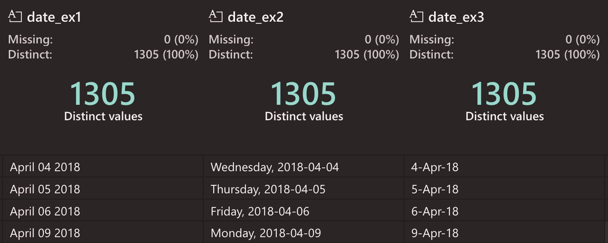

```python
financial['date_ex1_dt'] = pd.to_datetime(financial["date_ex1"], format = "%B %d %Y")
print(financial['date_ex1_dt'].head(3))
```

```
0   2018-04-04
1   2018-04-05
2   2018-04-06
Name: date_ex1_dt, dtype: datetime64[ns]
```

```python
financial['date_ex2_dt'] = pd.to_datetime(financial["date_ex2"], format = "%A, %Y-%m-%d")
print(financial['date_ex2_dt'].head())
```

```
0   2018-04-04
1   2018-04-05
2   2018-04-06
3   2018-04-09
4   2018-04-10
Name: date_ex2_dt, dtype: datetime64[ns]
```

## Parsing + wildcards

- Does the following line of code work?
- `pd.to_datetime(financial["date_ex1"], format = "%A, %Y-%m-%d")`
- No, it doesn’t work
- Why not?

```
ValueError: time data "April 04 2018" doesn't match format "%A, %Y-%m-%d", at position 0. You might want to try:
    - passing `format` if your strings have a consistent format;
    - passing `format='ISO8601'` if your strings are all ISO8601 but not necessarily in exactly the same format;
    - passing `format='mixed'`, and the format will be inferred for each element individually. You might want to use `dayfirst` alongside this.
```

## Period grouping

- We can group time series data by periods
- For example, we can group data by month or year
- First, you should specify the period you want to group by
- We use `pd.Grouper()` to group the data, then we use the `agg()` function to calculate the aggregate

```python
# Group the data by year
year_group = pd.Grouper(key='date', freq='YE') # 'YE' stands for year end
financial.groupby(year_group).agg(sp500_mean = ("sp500","mean")).reset_index()
```

|  | date | sp500_mean |
| --- | --- | --- |
| 0 | 2018-12-31 | 2751.921862 |
| 1 | 2019-12-31 | 2913.360556 |
| 2 | 2020-12-31 | 3217.856482 |
| 3 | 2021-12-31 | 4273.406627 |
| 4 | 2022-12-31 | 4098.514741 |
| 5 | 2023-12-31 | 4003.579844 |

- You can also group by month, week, day, quarter, etc.
- More information can be found [here](https://pandas.pydata.org/pandas-docs/stable/reference/api/pandas.Grouper.html)

## Plot the aggregated data

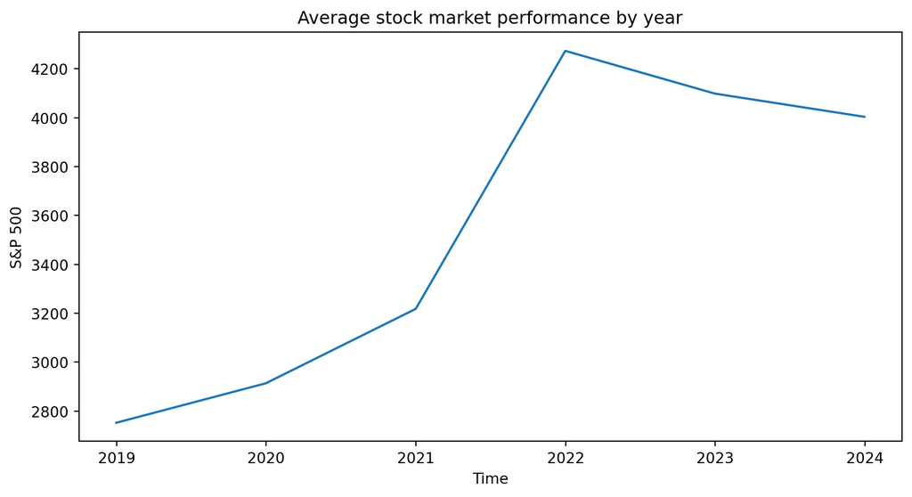

```python
plt.plot("date","sp500_mean",
          data = financial.groupby(year_group).agg(sp500_mean = ("sp500","mean")).reset_index())
plt.xlabel("Time")
plt.ylabel("S&P 500")
plt.title("Average stock market performance by year")
plt.show()
```

## Period grouping

### Another example

```python
month_group = pd.Grouper(key='date', freq='ME')

monthly_data = (financial
               .groupby(month_group)
               .agg(sp500_mean = ("sp500", "mean"))
               .reset_index())

monthly_data
```

|  | date | sp500_mean |
| --- | --- | --- |
| 0 | 2018-04-30 | 2659.463158 |
| 1 | 2018-05-31 | 2701.493636 |
| 2 | 2018-06-30 | 2754.352857 |
| 3 | 2018-07-31 | 2793.643333 |
| 4 | 2018-08-31 | 2857.820435 |
| ... | ... | ... |
| 56 | 2022-12-31 | 3912.380952 |
| 57 | 2023-01-31 | 3960.656500 |
| 58 | 2023-02-28 | 4079.684737 |
| 59 | 2023-03-31 | 3968.559130 |
| 60 | 2023-04-30 | 4112.555000 |

61 rows × 2 columns

## Plot the aggregated data

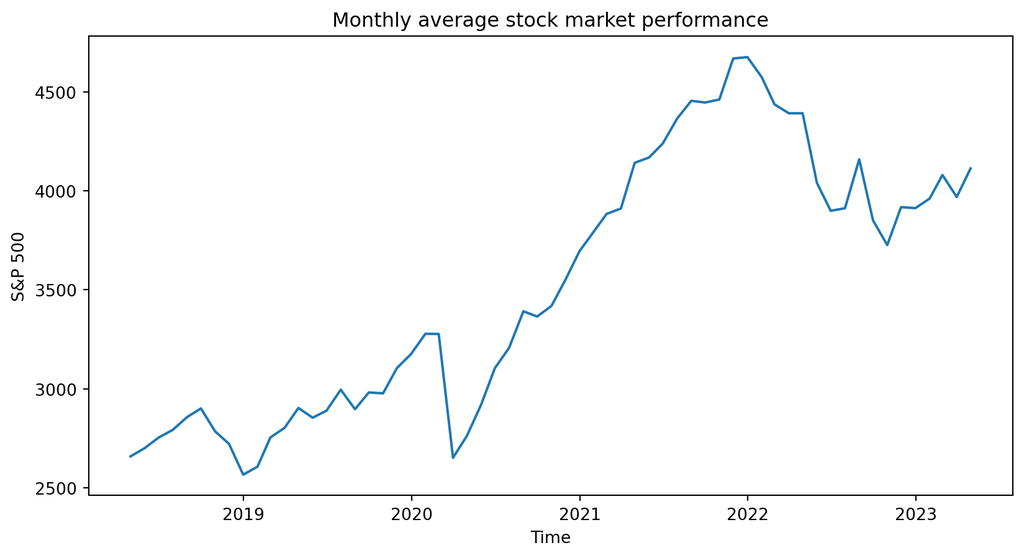

```python
plt.plot("date","sp500_mean",
          data = monthly_data)
plt.xlabel("Time")
plt.ylabel("S&P 500")
plt.title("Monthly average stock market performance")
plt.show()
```

## Try it yourself! 🧠

- Practice `pd.to_datetime()`
- Parse the column `data_ex3` to a `datetime` object
- Take a close look at the formatting
- HINT: Refer to the table of wildcards in the previous section
- Then, compute an aggregate dataset which calculates the standard deviation of the S&P 500 at the weekly level
- Generate a line plot with your results
- Appendix 03

# That’s all for today! 🎉

# See you next time! 👋

## Appendix 01

- Here is the solution to the exercise

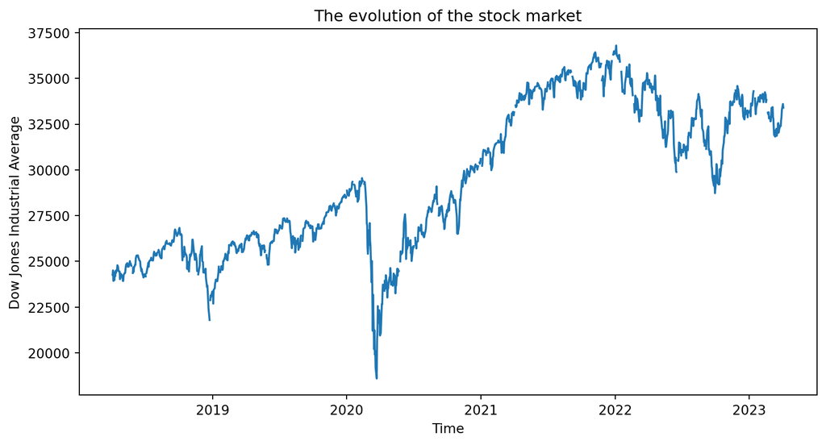

```python
# Sort the data
financial = financial.sort_values("date")

# Plot the data
plt.plot("date", "djia", data = financial)
plt.xlabel("Time")
plt.ylabel("Dow Jones Industrial Average")
plt.title("The evolution of the stock market")
plt.show()
```

Back to exercise

## Appendix 02

- We will use the following format: `Weekday, Month Day, Year`

```python
financial["date_test"] = financial["date"].dt.strftime("%A, %B %d, %Y")
print(financial["date_test"].head())
```

```
0    Wednesday, April 04, 2018
1     Thursday, April 05, 2018
2       Friday, April 06, 2018
3       Monday, April 09, 2018
4      Tuesday, April 10, 2018
Name: date_test, dtype: object
```

Back to exercise

## Appendix 03

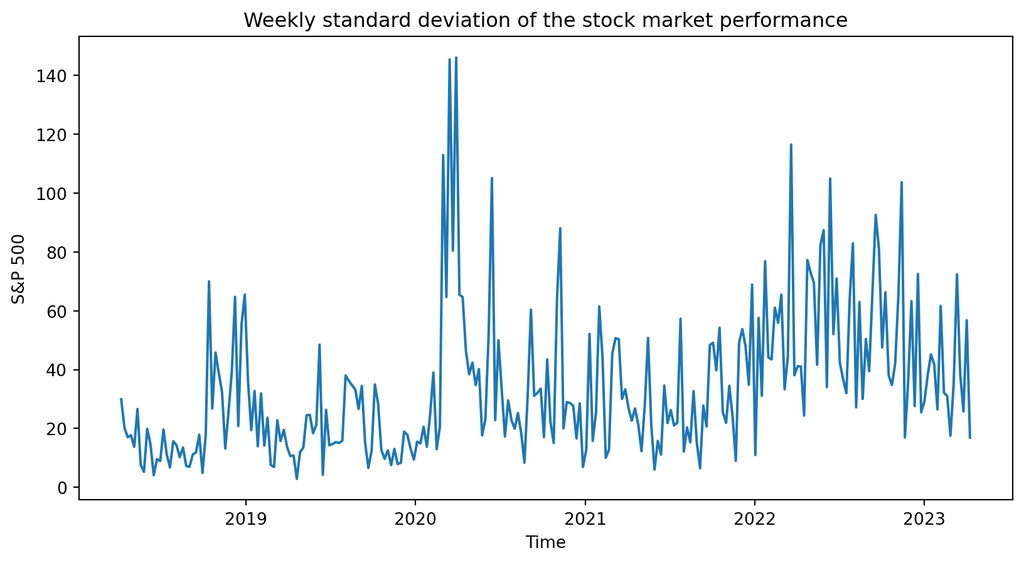

```python
financial['date_ex3_dt'] = pd.to_datetime(financial["date_ex3"], format = "%d-%b-%y")

week_group = pd.Grouper(key='date_ex3_dt', freq='W')

weekly_data = (financial
               .groupby(week_group)
               .agg(sp500_std = ("sp500", "std"))
               .reset_index())

plt.plot("date_ex3_dt","sp500_std",
          data = weekly_data)
plt.xlabel("Time")
plt.ylabel("S&P 500")
plt.title("Weekly standard deviation of the stock market performance")
plt.show()
```

Back to exercise